# Aliança Catalana 2024: Anàlisi exploratòria municipal

Distribució del vot i factors associats als 947 municipis de Catalunya

Autor/a

Afiliació

Jordi Muñoz

Universitat de Barcelona

# Distribució territorial del vot a Aliança Catalana (2024)

En aquesta pàgina hi presento més detalls de l’anàlisi de dades en què es basa l’article “Del carlisme a la Xenofòbia” publicat al diari Ara. En primer lloc, s’hi mostra la distribució territorial del vot a AC, seguida de dues projeccions basades en el darrer baròmetre publicat pel Centre d’Estudis d’Opinió. La primera es basa exclusivament en el record de vot, i la segona té en compte altres variables, i empra el mètode de la regressió multinivell amb post-estratificació.

En tercer lloc, explorem els factors que, a nivell municipal, correlacionen amb la penetració d’AC, tant a nivell bivariat com en un seguit de models multivariant. Ens fixem en factors com la davallada electoral de l’independentisme després del procés, factors socioeconòmics i territorials, i l’herència històrica del carlisme.

Finalment, també presento una anàlisi de les dades individuals de l’enquesta del CEO (3a onada del Baròmetre d’Opinió Política de 2025).

## Mapes del vot a AC

Els dos mapes mostren la distribució territorial del vot a Aliança Catalana a les eleccions al Parlament de Catalunya del 2024, expressada de dues maneres: com a percentatge dels vots vàlids a candidatures i com a percentatge del cens electoral (que penalitza la baixa participació).

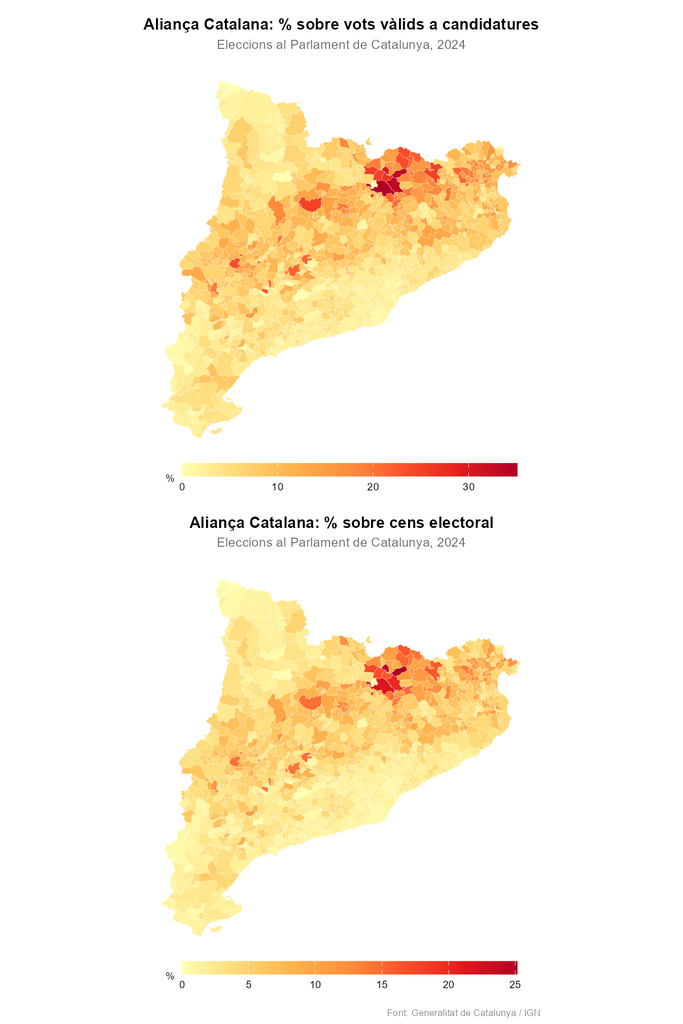

Font: Generalitat de Catalunya / IGN

## Distribució general del vot

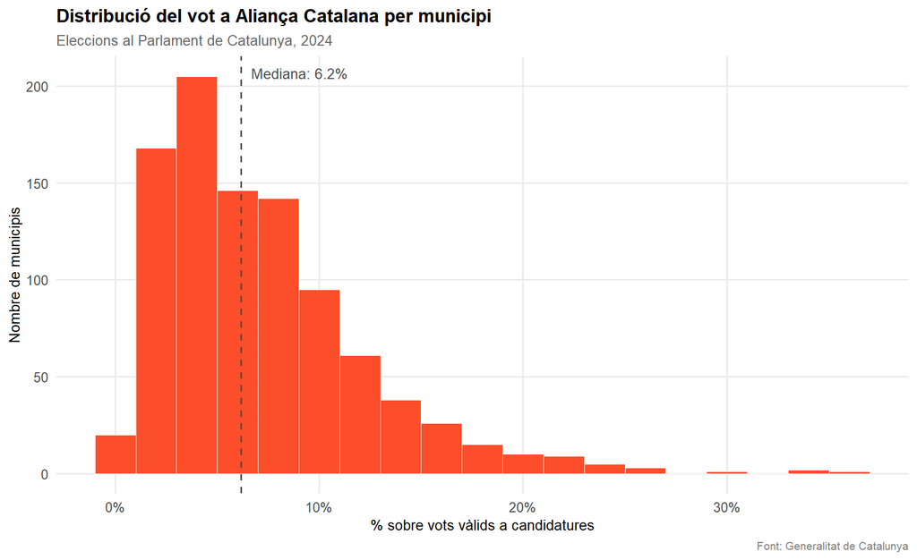

Distribució del percentatge de vot a AC sobre vots vàlids a candidatures. Cada barra representa un interval de 2 punts percentuals.

Quintils del vot a Aliança Catalana

El Q1 agrupa els municipis amb menys vot AC; el Q5, els que en tenen més

| Quintil | Núm. municipis | Vot AC mínim (%) | Vot AC màxim (%) | Vot AC mediana (%) | Població total |
| --- | --- | --- | --- | --- | --- |
| Q1 (menys vot AC) | 190 | 0.0 | 3.0 | 2.1 | 4.938.398 |
| Q2 | 190 | 3.0 | 4.9 | 3.9 | 1.195.411 |
| Q3 | 189 | 4.9 | 7.3 | 6.2 | 820.020 |
| Q4 | 189 | 7.3 | 10.7 | 8.8 | 615.223 |
| Q5 (més vot AC) | 189 | 10.7 | 35.1 | 13.9 | 340.073 |

Font: Generalitat de Catalunya (2024)

# Projeccions de vot municipal

## Vot projectat a Aliança Catalana (model de transferències CEO)

Aquesta secció replica l’anàlisi anterior substituint el vot real del 2024 per un **vot projectat**: quin seria el suport a AC si les taxes de transferència observades a l’Estudi 1145 del CEO s’apliquessin a la composició electoral de cada municipi. Per a cada municipi, el vot projectat és la suma ponderada dels vots de cada opció del 2024 multiplicats per la probabilitat que un votant d’aquella opció declari que avui votaria AC. El denominador és el total de vots vàlids a candidatures (equivalent a `ac_share_vot`).

Les taxes globals usades (Catalunya sencera) són: PSC 3,1 %, ERC 7,0 %, Junts 21,2 %, PP 5,0 %, Comuns 0,0 %, CUP 1,6 %, VOX 9,1 %, AC 87,1 %, Altres 9,1 %, En blanc 9,1 %, Vot nul 0,0 %, No va votar 10,6 % (inclòs en la versió cens). La correlació de Pearson entre el vot real i el projectat és **r = 0,94**.

### Mapa del vot projectat

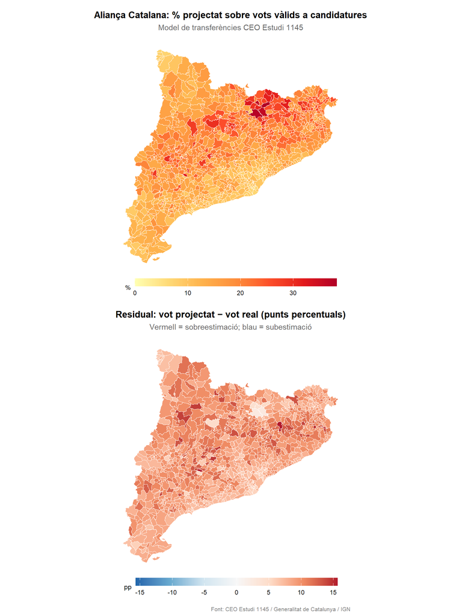

Font: CEO Estudi 1145 / Generalitat de Catalunya / IGN

### Distribució del vot projectat

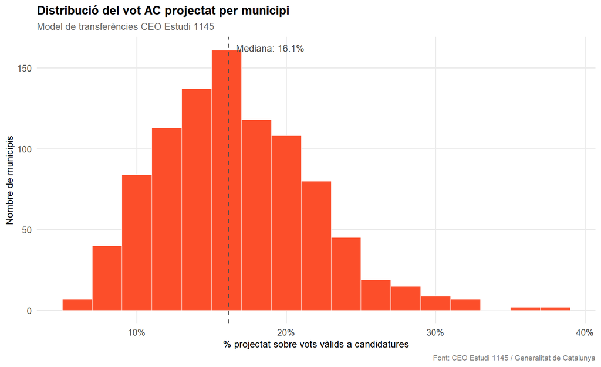

Distribució del vot AC projectat. Cada barra representa un interval de 2 punts percentuals.

Quintils del vot AC projectat

El Q1 agrupa els municipis amb menys vot AC projectat; el Q5, els que en tenen més

| Quintil | Núm. municipis | Vot AC proj. mínim (%) | Vot AC proj. màxim (%) | Vot AC proj. mediana (%) | Població total |
| --- | --- | --- | --- | --- | --- |
| Q1 (menys vot AC) | 190 | 6.2 | 12.1 | 10.3 | 5.596.900 |
| Q2 | 190 | 12.1 | 15.0 | 13.5 | 947.975 |
| Q3 | 189 | 15.0 | 17.5 | 16.1 | 522.991 |
| Q4 | 189 | 17.5 | 20.5 | 19.1 | 548.914 |
| Q5 (més vot AC) | 189 | 20.5 | 38.2 | 23.3 | 292.345 |

Font: CEO Estudi 1145 / Generalitat de Catalunya (2024)

### Comparació: vot real vs. vot projectat

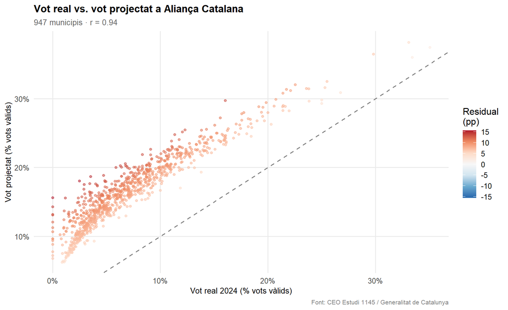

Cada punt és un municipi. La línia discontínua és la bisectriu (vot real = vot projectat).

### Vot 2024 i projecció, per comarques

| # | Comarca | 2024 (%) | Proj. (%) |
| --- | --- | --- | --- |
| 1 | Ripollès | 25.2 | 30.8 |
| 2 | Garrotxa | 15.3 | 24.0 |
| 3 | Pla d’Urgell | 12.5 | 21.2 |
| 4 | Alt Empordà | 10.6 | 18.5 |
| 5 | Osona | 10.2 | 20.3 |
| 6 | Berguedà | 10.1 | 19.6 |
| 7 | Urgell | 9.9 | 19.6 |
| 8 | Pla de l’Estany | 9.9 | 20.6 |
| 9 | Noguera | 9.7 | 18.7 |
| 10 | Solsonès | 9.3 | 19.1 |
| 11 | Lluçanès | 8.8 | 20.1 |
| 12 | Bages | 8.6 | 16.7 |
| 13 | Segarra | 8.6 | 18.0 |
| 14 | Cerdanya | 8.2 | 17.5 |
| 15 | Segrià | 7.4 | 15.3 |
| 16 | Garrigues | 7.3 | 17.4 |
| 17 | Baix Empordà | 7.2 | 16.4 |
| 18 | Gironès | 7.0 | 16.7 |
| 19 | Selva | 6.5 | 15.0 |
| 20 | Moianès | 5.9 | 15.6 |
| 21 | Baix Ebre | 5.1 | 13.5 |
| 22 | Pallars Jussà | 5.1 | 15.4 |
| 23 | Conca de Barberà | 5.1 | 15.3 |
| 24 | Alt Camp | 4.9 | 14.0 |
| 25 | Alt Penedès | 4.7 | 13.4 |
| 26 | Alt Urgell | 4.7 | 13.9 |
| 27 | Priorat | 4.7 | 14.3 |
| 28 | Alta Ribagorça | 4.6 | 12.7 |
| 29 | Ribera d’Ebre | 4.4 | 13.6 |
| 30 | Anoia | 4.2 | 12.3 |
| 31 | Baix Camp | 4.2 | 12.2 |
| 32 | Maresme | 3.7 | 12.1 |
| 33 | Montsià | 3.7 | 11.9 |
| 34 | Vallès Oriental | 3.2 | 11.0 |
| 35 | Pallars Sobirà | 3.0 | 13.2 |
| 36 | Garraf | 2.6 | 10.0 |
| 37 | Vallès Occidental | 2.6 | 9.9 |
| 38 | Baix Penedès | 2.6 | 9.9 |
| 39 | Tarragonès | 2.5 | 9.7 |
| 40 | Terra Alta | 2.1 | 11.4 |
| 41 | Barcelonès | 1.9 | 8.9 |
| 42 | Aran | 1.8 | 8.6 |
| 43 | Baix Llobregat | 1.7 | 8.2 |

## Vot estimat per MRP (regressió multinivell amb postestratificació)

Ara repliquem l’anàlisi anterior substituint el vot real i el vot projectat per transferències per un **vot estimat via MRP** (*multilevel regression with poststratification*): un model `glmer` ajustat amb les dades individuals del CEO 1145 que prediu la probabilitat de votar AC en funció del record de vot 2024, el sexe, el grup d’edat i el lloc de naixement, amb efectes aleatoris per grup d’edat i comarca/municipi. El marc de postestratificació combina els marges demogràfics del Padró INE 2024 i la distribució real del vot per municipi.

### Mapa del vot estimat per MRP

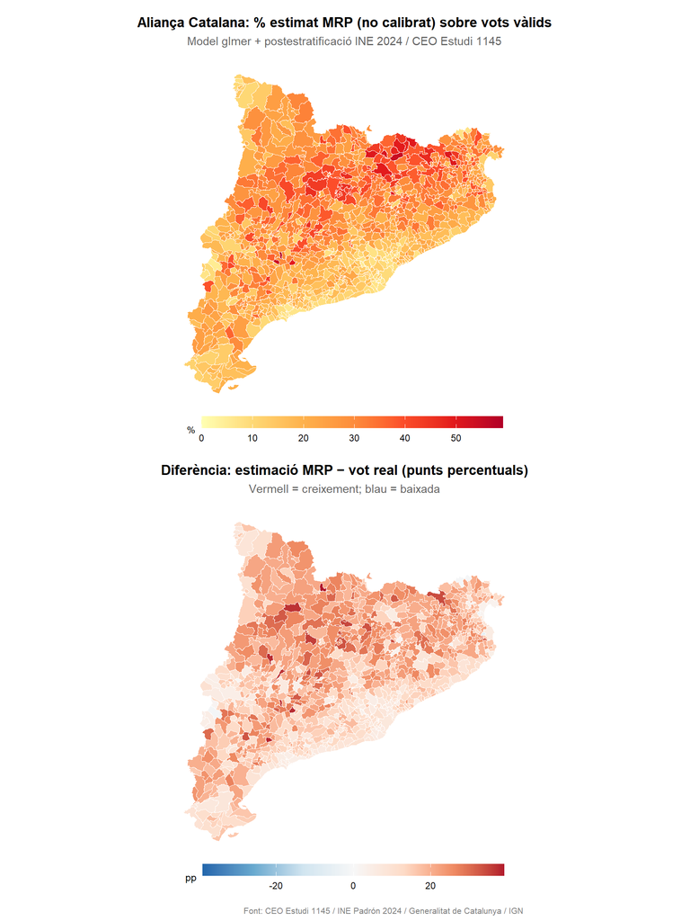

Font: CEO Estudi 1145 / INE Padrón 2024 / Generalitat de Catalunya / IGN

### Distribució del vot estimat per MRP

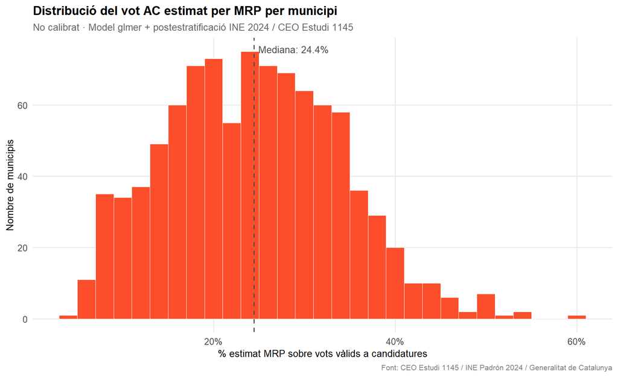

Distribució del vot AC estimat per MRP (no calibrat). Cada barra representa un interval de 2 punts percentuals.

Quintils del vot AC estimat per MRP (no calibrat)

El Q1 agrupa els municipis amb menys vot AC estimat; el Q5, els que en tenen més

| Quintil | Núm. municipis | Vot MRP mínim (%) | Vot MRP màxim (%) | Vot MRP mediana (%) | Població total |
| --- | --- | --- | --- | --- | --- |
| Q1 (menys vot AC) | 190 | 4.3 | 15.8 | 11.8 | 6.389.259 |
| Q2 | 190 | 15.8 | 21.3 | 18.5 | 821.452 |
| Q3 | 189 | 21.4 | 26.9 | 24.5 | 368.567 |
| Q4 | 189 | 26.9 | 32.9 | 29.7 | 208.171 |
| Q5 (més vot AC) | 189 | 32.9 | 59.1 | 36.5 | 121.676 |

Font: CEO Estudi 1145 / INE Padrón 2024 / Generalitat de Catalunya (2024)

### Comparació: vot 2024 vs. estimació MRP

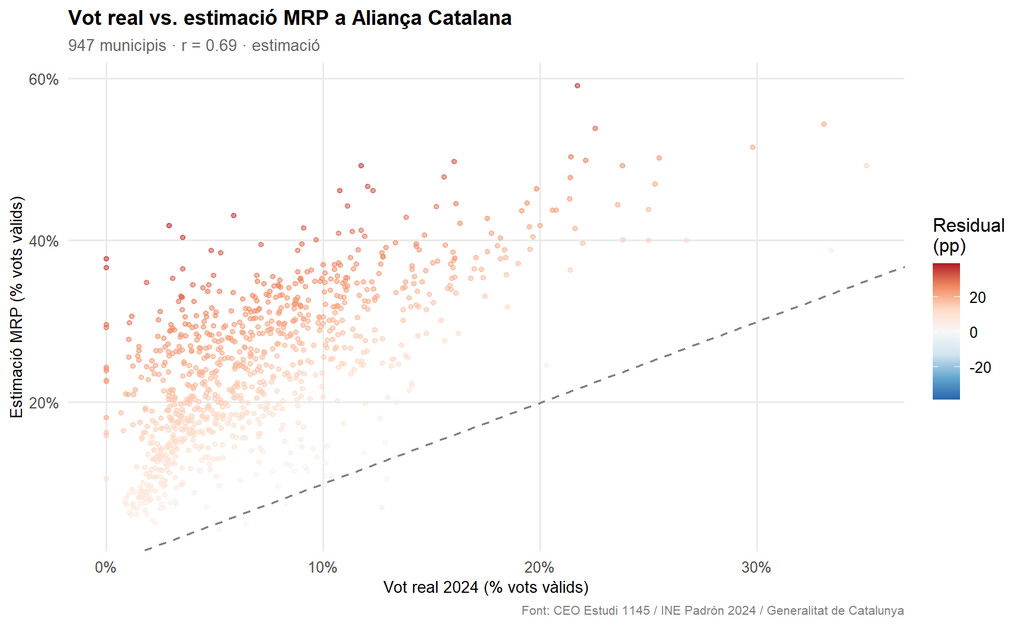

Cada punt és un municipi. La línia discontínua és la bisectriu (vot real = estimació MRP). L’estimació no calibrada és sistemàticament superior al vot real.

# Característiques dels municipis i vot a AC

En aquesta part de l’anàlisi explorem quines característiques dels municipis correlacionen amb el vot a Aliança Catalana. Aquest estudi de correlacions ens pot donar pistes explicatives. Primer mostrem la distribució d’una selecció de característiques municipals per quartil de vot a AC, i després mostrarem una sèrie de models de regressió en què hi emergeixen les correlacions parcials, controlant uns factors pels altres.

## Distribució de variables explicatives, per quartils de vot a AC

Valors mitjans de sis indicadors clau per a cada quartil de municipis ordenats de major a menor vot a Aliança Catalana el 2024. El Q4 engloba el 25 % de municipis amb més suport a AC; el Q1, el 25 % amb menys.

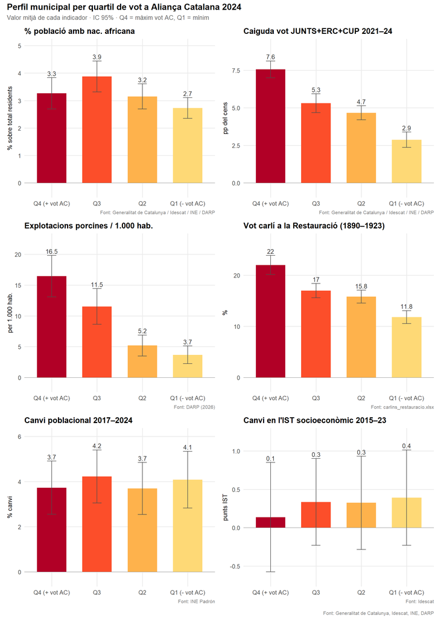

Valor mitjà per quartil de vot a AC. Q4 = 25% de municipis amb màxim suport; Q1 = 25% amb mínim suport. Barres d’error: IC 95%.

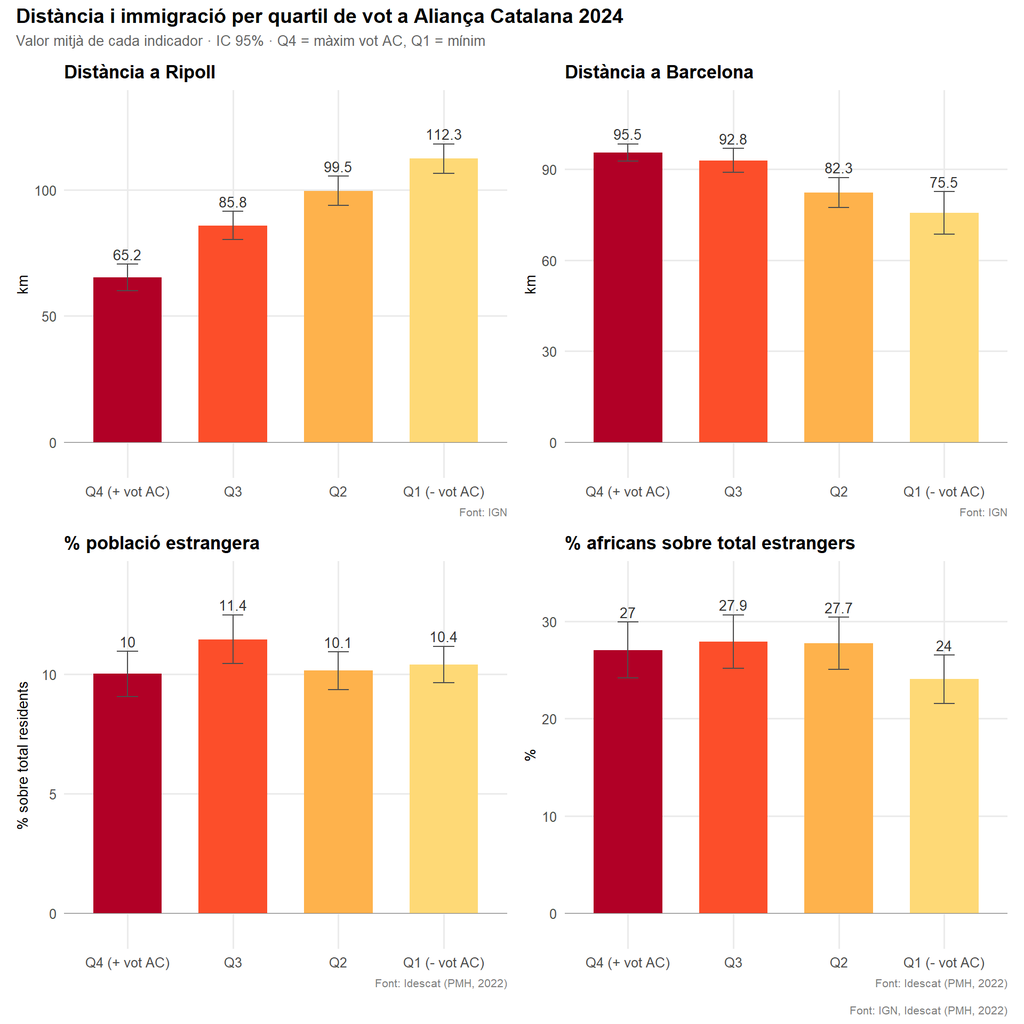

Distància, immigració total i composició per quartil de vot a AC. Barres d’error: IC 95%.

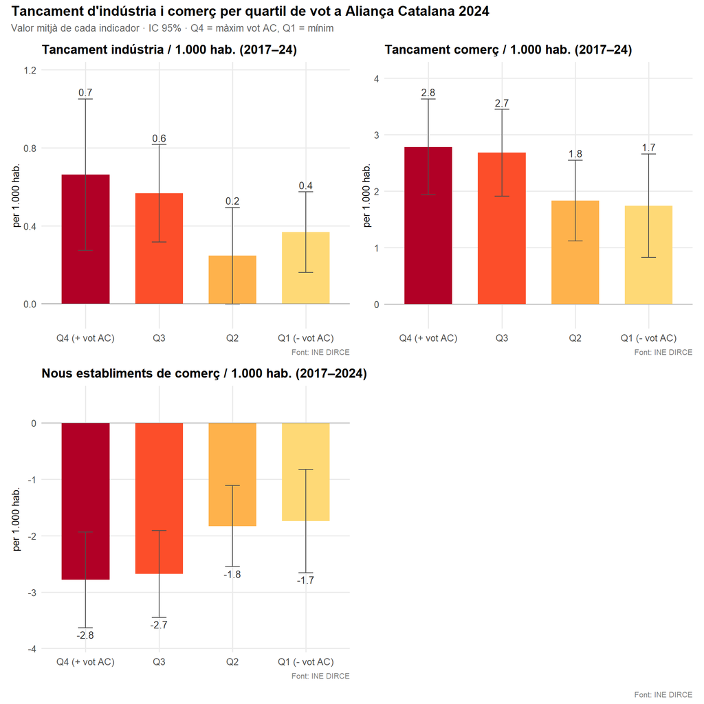

Tancament d’establiments industrials i comercials (2017–2024) per quartil de vot a AC. Barres d’error: IC 95%.

## Vot a AC per quartils de cada variable explicativa

Vot mitjà a Aliança Catalana el 2024 (% sobre vots a candidatures) per a cada quartil de sis indicadors clau. El Q4 engloba el 25 % de municipis amb el valor més alt de cada indicador; el Q1, el 25 % amb el valor més baix.

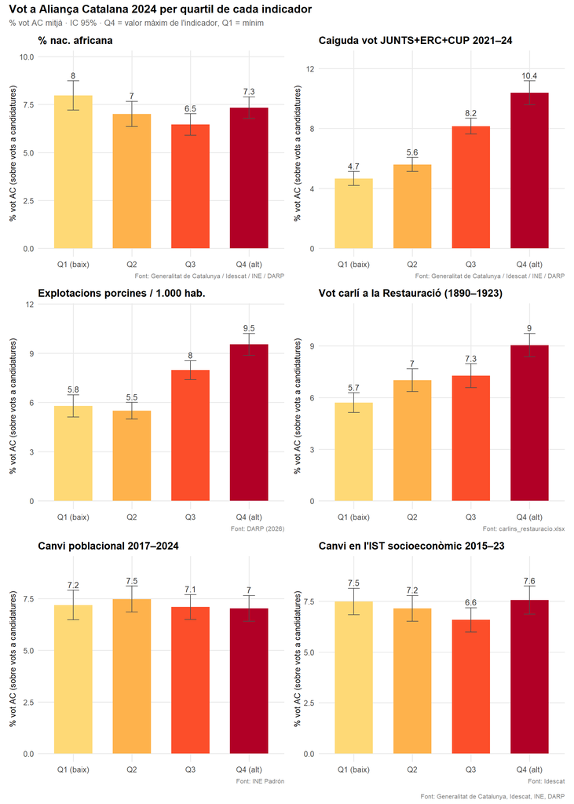

Vot mitjà a AC per quartil de cada indicador. Q4 = 25% de municipis amb valor més alt; Q1 = 25% amb valor més baix. Barres d’error: IC 95%.

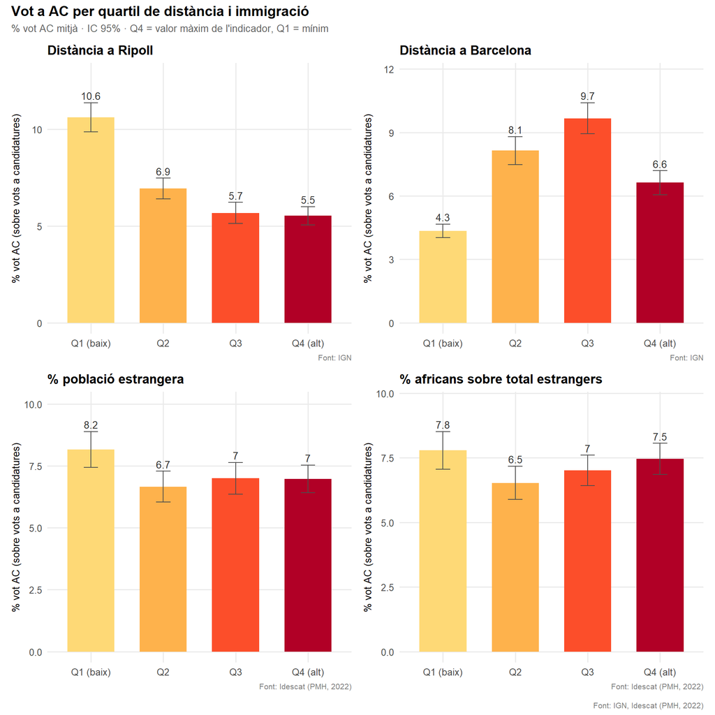

Vot mitjà a AC per quartil de distància i immigració. Barres d’error: IC 95%.

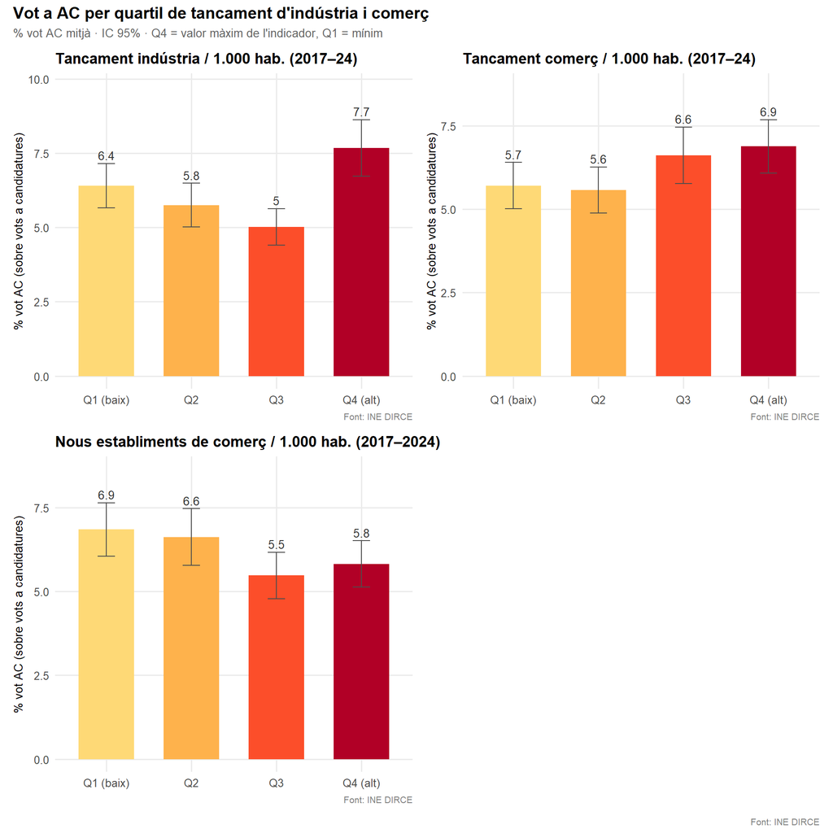

Vot mitjà a AC per quartil de tancament d’establiments industrials i comercials (2017–2024). Barres d’error: IC 95%.

## Models de regressió multivariant

Models OLS estimats per als tres outcomes: vot real 2024, vot projectat (model simple de transferències CEO) i estimació MRP. Les especificacions s’amplien progressivament:

Els errors estàndard són HC1 (M1–M2) i agrupats per comarca (M3–M4).

### Vot real 2024

Determinants del vot a AC 2024 (especificació revisada) — % vot real

|  | (M1) Geogràfic | (M2) Complet | (M3) FE comarca | (M4) + Tancament comerç |
| --- | --- | --- | --- | --- |
| Vot carlí Restauració (% totes elect.) | 0.029** | 0.027** | 0.044*** | 0.045*** |
|  | (0.014) | (0.013) | (0.014) | (0.014) |
| Distància a Ripoll (km) | -0.041*** | -0.044*** | -0.053** | -0.075*** |
|  | (0.004) | (0.005) | (0.024) | (0.028) |
| Població 2024 (log) | -0.674*** | -0.738*** | -0.146 | 0.258** |
|  | (0.099) | (0.156) | (0.148) | (0.113) |
| Vot independentista 2021 (%) |  | -0.061 | -0.070 | -0.004 |
|  |  | (0.038) | (0.044) | (0.039) |
| Caiguda indep. 2021–24 (pp) |  | 0.326*** | 0.225*** | 0.446*** |
|  |  | (0.055) | (0.057) | (0.123) |
| % vot VOX 2021 |  | -0.147** | -0.132* | -0.135** |
|  |  | (0.074) | (0.072) | (0.061) |
| % població estrangera |  | 0.141*** | 0.022 | 0.015 |
|  |  | (0.037) | (0.043) | (0.032) |
| % africana s/ estrangers |  | 0.015* | 0.010 | 0.011 |
|  |  | (0.008) | (0.010) | (0.011) |
| Mesquites / 1.000 hab. |  | -0.250 | -0.849 | 0.011 |
|  |  | (1.000) | (0.600) | (1.240) |
| Explot. porcines / 1.000 hab. |  | 0.029*** | 0.020** | -0.028 |
|  |  | (0.009) | (0.009) | (0.039) |
| Canvi poblacional 2017–24 (%) |  | -0.049** | -0.031* | 0.005 |
|  |  | (0.021) | (0.018) | (0.020) |
| IST socioeconòmic (100 = Cat.) |  | 0.009 | 0.038 | 0.017 |
|  |  | (0.027) | (0.033) | (0.021) |
| Canvi IST 2015–23 (punts) |  | 0.032 | 0.009 | 0.051 |
|  |  | (0.040) | (0.036) | (0.049) |
| % 65 anys i més |  | -0.024 | -0.099*** | -0.127** |
|  |  | (0.042) | (0.036) | (0.053) |
| Tancament comerç (2017–24) |  |  |  | 0.024* |
|  |  |  |  | (0.012) |
| N | 886 | 879 | 879 | 430 |
| R² | 0.225 | 0.351 | 0.595 | 0.835 |
| R² (within) |  |  | 0.118 | 0.405 |

* p < 0.1, ** p < 0.05, *** p < 0.01  
Errors estàndard HC1 (M1–M2); agrupats per comarca (M3–M4). M3–M4 inclouen 42 efectes fixos de comarca.  
* p<0,10 ** p<0,05 *** p<0,01

### Vot projectat (model de transferències CEO)

Determinants del vot a AC 2024 (especificació revisada) — % vot projectat

|  | (M1) Geogràfic | (M2) Complet | (M3) FE comarca | (M4) + Tancament comerç |
| --- | --- | --- | --- | --- |
| Vot carlí Restauració (% totes elect.) | 0.046*** | 0.029** | 0.043*** | 0.043*** |
|  | (0.013) | (0.012) | (0.012) | (0.012) |
| Distància a Ripoll (km) | -0.045*** | -0.045*** | -0.048** | -0.074*** |
|  | (0.003) | (0.004) | (0.019) | (0.023) |
| Població 2024 (log) | -1.094*** | -0.653*** | -0.094 | 0.190* |
|  | (0.094) | (0.134) | (0.135) | (0.111) |
| Vot independentista 2021 (%) |  | 0.076** | 0.065* | 0.156*** |
|  |  | (0.032) | (0.037) | (0.033) |
| Caiguda indep. 2021–24 (pp) |  | 0.169*** | 0.082 | 0.200* |
|  |  | (0.047) | (0.052) | (0.099) |
| % vot VOX 2021 |  | -0.111* | -0.087 | -0.074 |
|  |  | (0.064) | (0.060) | (0.056) |
| % població estrangera |  | 0.131*** | 0.020 | 0.029 |
|  |  | (0.033) | (0.038) | (0.030) |
| % africana s/ estrangers |  | 0.012 | 0.007 | 0.009 |
|  |  | (0.008) | (0.009) | (0.010) |
| Mesquites / 1.000 hab. |  | 0.003 | -0.571 | 0.342 |
|  |  | (1.005) | (0.553) | (1.088) |
| Explot. porcines / 1.000 hab. |  | 0.038*** | 0.025*** | -0.036 |
|  |  | (0.009) | (0.009) | (0.038) |
| Canvi poblacional 2017–24 (%) |  | -0.044** | -0.031** | 0.018 |
|  |  | (0.018) | (0.014) | (0.018) |
| IST socioeconòmic (100 = Cat.) |  | -0.005 | 0.028 | 0.021 |
|  |  | (0.024) | (0.029) | (0.019) |
| Canvi IST 2015–23 (punts) |  | 0.008 | -0.017 | 0.037 |
|  |  | (0.037) | (0.031) | (0.046) |
| % 65 anys i més |  | -0.025 | -0.085** | -0.117** |
|  |  | (0.037) | (0.037) | (0.050) |
| Tancament comerç (2017–24) |  |  |  | 0.017 |
|  |  |  |  | (0.015) |
| N | 886 | 879 | 879 | 430 |
| R² | 0.352 | 0.508 | 0.698 | 0.895 |
| R² (within) |  |  | 0.210 | 0.597 |

* p < 0.1, ** p < 0.05, *** p < 0.01  
Errors estàndard HC1 (M1–M2); agrupats per comarca (M3–M4). M3–M4 inclouen 42 efectes fixos de comarca.  
* p<0,10 ** p<0,05 *** p<0,01

### Estimació MRP (model glmer + postestratificació)

Determinants del vot a AC 2024 (especificació revisada) — estimació MRP

|  | (M1) Geogràfic | (M2) Complet | (M3) FE comarca | (M4) + Tancament comerç |
| --- | --- | --- | --- | --- |
| Vot carlí Restauració (% totes elect.) | 0.061*** | 0.048*** | 0.058*** | 0.047** |
|  | (0.020) | (0.016) | (0.020) | (0.019) |
| Distància a Ripoll (km) | -0.072*** | -0.058*** | -0.084*** | -0.108*** |
|  | (0.005) | (0.005) | (0.021) | (0.021) |
| Població 2024 (log) | -3.473*** | -1.835*** | -1.241*** | -0.575*** |
|  | (0.136) | (0.177) | (0.180) | (0.135) |
| Vot independentista 2021 (%) |  | 0.062 | 0.029 | 0.219*** |
|  |  | (0.041) | (0.044) | (0.046) |
| Caiguda indep. 2021–24 (pp) |  | 0.351*** | 0.267*** | 0.319*** |
|  |  | (0.062) | (0.069) | (0.111) |
| % vot VOX 2021 |  | -0.395*** | -0.312*** | -0.147 |
|  |  | (0.087) | (0.071) | (0.092) |
| % població estrangera |  | -0.213*** | -0.327*** | -0.268*** |
|  |  | (0.043) | (0.047) | (0.034) |
| % africana s/ estrangers |  | -0.132*** | -0.138*** | -0.150*** |
|  |  | (0.012) | (0.015) | (0.017) |
| Mesquites / 1.000 hab. |  | -2.712** | -3.362*** | -1.451 |
|  |  | (1.242) | (0.794) | (1.424) |
| Explot. porcines / 1.000 hab. |  | 0.053*** | 0.035*** | 0.016 |
|  |  | (0.013) | (0.012) | (0.048) |
| Canvi poblacional 2017–24 (%) |  | -0.068** | -0.045** | -0.003 |
|  |  | (0.026) | (0.020) | (0.028) |
| IST socioeconòmic (100 = Cat.) |  | -0.130*** | -0.064 | -0.061* |
|  |  | (0.031) | (0.039) | (0.032) |
| Canvi IST 2015–23 (punts) |  | -0.016 | -0.056 | 0.110 |
|  |  | (0.056) | (0.052) | (0.074) |
| % 65 anys i més |  | 0.020 | -0.062 | -0.079 |
|  |  | (0.051) | (0.052) | (0.070) |
| Tancament comerç (2017–24) |  |  |  | -0.003 |
|  |  |  |  | (0.026) |
| N | 886 | 879 | 879 | 430 |
| R² | 0.569 | 0.736 | 0.824 | 0.918 |
| R² (within) |  |  | 0.651 | 0.821 |

* p < 0.1, ** p < 0.05, *** p < 0.01  
Errors estàndard HC1 (M1–M2); agrupats per comarca (M3–M4). M3–M4 inclouen 42 efectes fixos de comarca. Estimació MRP no calibrada.  
* p<0,10 ** p<0,05 *** p<0,01

Els coeficients s´interpreten com a punts percentuals de vot a AC per desviació estàndard del predictor. Els tres outcomes utilitzen el model M4 (efectes fixos de comarca, errors agrupats). Les barres mostren l’interval de confiança del 95%.

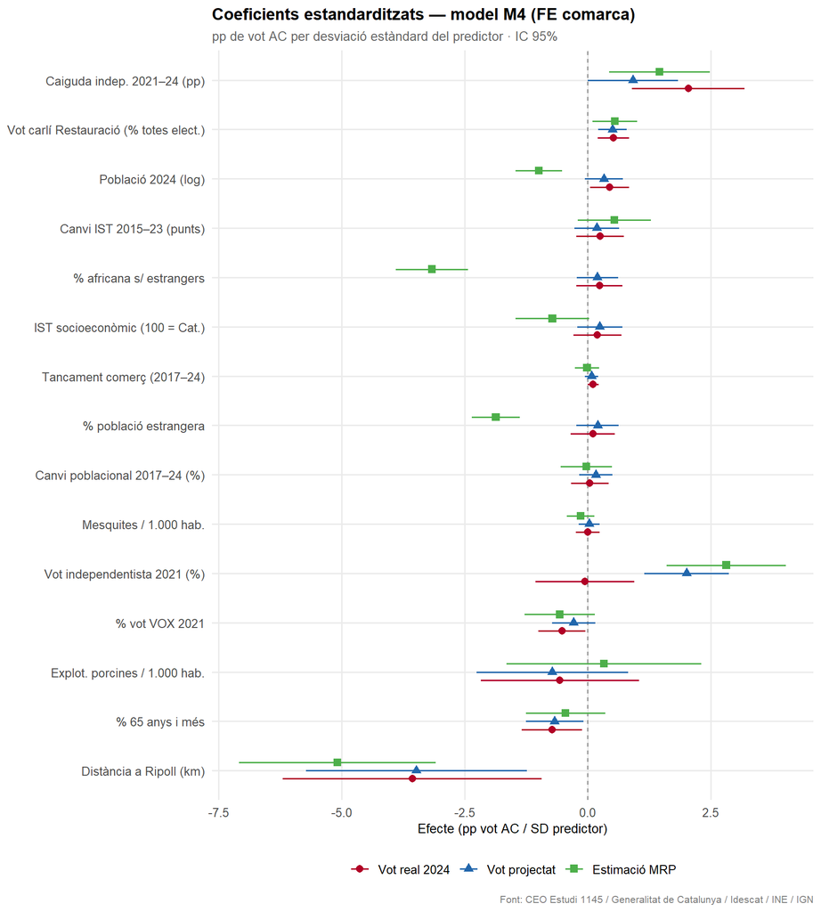

# Anàlisi individual: qui vota Aliança Catalana (CEO 1145)

L’Estudi 1145 del Centre d’Estudis d’Opinió (CEO) conté la intenció de vot i un perfil sociodemogràfic i ideològic detallat de la ciutadania catalana. Aquesta secció analitza qui declara la intenció de votar AC i en quina mesura diverses característiques individuals s’associen a aquest suport. Es presenten tres models de probabilitat lineal (OLS) ponderat (ponderació PONDERA del CEO) que comparen l’electorat d’AC contra: (M1) la resta de partits, (M2) els partits independentistes tradicionals (Junts, ERC, CUP) i (M3) VOX. Els coeficients s’interpreten directament com a diferències en punts percentuals de probabilitat de votar AC respecte a la categoria de referència. S’utilitzen errors estàndard robustos (HC1).

## Perfil sociodemogràfic i ideològic

El gràfic mostra, per a cada subgrup, el percentatge ponderat de persones que declaren la intenció de votar AC (sobre el total d’enquestats amb intenció de vot a un partit, N = 1.477).

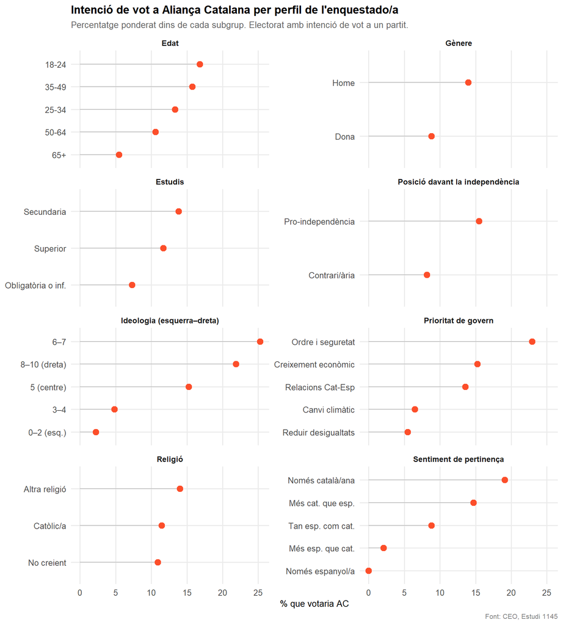

Font: CEO, Estudi 1145. Dades ponderades.

## Models de probabilitat lineal (OLS)

Determinants individuals del vot a Aliança Catalana — model de probabilitat lineal (OLS)

|  | (M1) AC vs. resta | (M2) vs. Junts/ERC/CUP | (M3) AC vs. VOX |
| --- | --- | --- | --- |
| Edat: 18–24 (ref. 35–49) | -0.8 | 3.6 | -8.4 |
|  | (3.9) | (6.6) | (6.9) |
| Edat: 25–34 | -1.0 | -1.3 | 7.2 |
|  | (3.1) | (5.2) | (7.8) |
| Edat: 50–64 | -4.1* | -7.3* | 3.1 |
|  | (2.4) | (4.0) | (6.4) |
| Edat: 65+ | -7.4*** | -12.7*** | 5.9 |
|  | (2.5) | (4.5) | (7.4) |
| Gènere: home (ref. dona) | 2.2 | 3.0 | 3.3 |
|  | (1.6) | (2.9) | (4.9) |
| Estudis: secundaria (ref. superior) | 2.4 | 4.5 | -13.2** |
|  | (2.1) | (3.5) | (5.5) |
| Estudis: obligatòria o inferior | -2.3 | 0.8 | -28.7*** |
|  | (2.3) | (4.2) | (7.1) |
| Vegueria: Girona (ref. Metrop.) | 1.7 | 2.5 | -1.5 |
|  | (3.1) | (4.7) | (6.5) |
| Vegueria: Camp de Tarragona | -4.8* | -8.8 | -2.5 |
|  | (2.8) | (6.9) | (10.8) |
| Vegueria: Terres de l'Ebre | -1.4 | -6.9 | 69.6*** |
|  | (5.2) | (8.4) | (9.1) |
| Vegueria: Ponent | -5.2 | -11.0 | -14.4 |
|  | (5.0) | (7.9) | (8.9) |
| Vegueria: Comarques Centrals | 5.3 | 0.7 | 6.9 |
|  | (3.8) | (5.7) | (7.3) |
| Vegueria: Alt Pirineu i Aran | -9.9* | -12.9 | 22.0** |
|  | (5.4) | (8.5) | (9.5) |
| Ideologia (0 esq.–10 dreta) | 3.9*** | 8.0*** | -3.8*** |
|  | (0.5) | (0.9) | (1.4) |
| Pro-independència (ref. contrari/ària) | 1.8 | -8.8* | 2.4 |
|  | (2.2) | (4.6) | (8.2) |
| Prioritat: creixement econòmic (ref. desigualtats) | 6.9*** | 11.9*** | -0.7 |
|  | (2.2) | (4.4) | (6.6) |
| Prioritat: relacions Cat-Esp | 3.8 | 6.5 | -5.6 |
|  | (3.6) | (5.6) | (8.4) |
| Prioritat: ordre i seguretat | 14.0*** | 26.9*** | 1.8 |
|  | (2.8) | (5.3) | (6.3) |
| Prioritat: canvi climàtic | 1.8 | -1.7 | 12.6 |
|  | (3.0) | (5.9) | (11.8) |
| Religió: catòlic/a (ref. no creient) | 1.3 | 2.1 | -0.4 |
|  | (2.0) | (3.4) | (5.2) |
| Religió: altra religió | 0.2 | 1.4 | -6.1 |
|  | (3.6) | (7.3) | (8.3) |
| Pertinença: només espanyol/a (ref. tan esp. com cat.) | -12.4*** | -13.3** | -32.3*** |
|  | (2.1) | (6.5) | (5.9) |
| Pertinença: més esp. que cat. | -10.5*** | 0.1 | -19.5** |
|  | (2.3) | (7.3) | (7.8) |
| Pertinença: més cat. que esp. | 9.0*** | 2.2 | 48.0*** |
|  | (2.5) | (4.8) | (8.3) |
| Pertinença: només català/ana | 13.9*** | 8.1 | 44.6*** |
|  | (3.2) | (5.4) | (8.8) |
| N | 1302 | 638 | 266 |
| R² | 0.159 | 0.304 | 0.520 |

* p < 0.1, ** p < 0.05, *** p < 0.01  
OLS ponderat amb errors estàndard robustos HC1. Variable dependent: intenció de vot a AC (0/100). Coeficients en punts percentuals.  
Cat. referència: 35–49 anys, dona, estudis superiors, vegueria Metropolitana, contrari/ària a la independència, prioritat: reduir desigualtats, no creient, tan espanyol/a com català/ana. * p<0,10 ** p<0,05 *** p<0,01

*Dades: eleccions al Parlament de Catalunya 2024 Idescat, INE, DARP, IGN; CEO Estudi 1145 i Vall-Prat, Pau (2021), “Dataset of Historical Elections in Catalonia (DHEC)”, Mendeley Data, V2, doi: 10.17632/88vvxk4ydp.2*